# Informe del Proyecto entrega 3

Leidy Johanna Salazar Morales

19/12/2021

### Introducción

Este informe contiene el análisis de datos de un almacén, elaborado por medio del lenguaje de programación R.

```r
#nrow(Ventas) #número de filas del dataset Ventas
#ncol(Ventas) #número de columnas del dataset Ventas
```

El dataset Ventas comprende 12 variables y 1544 observaciones. Las variabales son:

- Mes
- Producto
- Código vendedor
- Tipo producto
- Tienda
- Sector
- Compra
- Monto venta
- Edad
- Género
- Punto de red
- Frecuencia

El dataset Vendedores comprende 2 variables y 5 observaciones. Las variables son:

- Código
- Nombre

### Problema a solucionar

Quiero saber si hay una correlación entre la edad y los montos de las ventas.

### Hipótesis a validar

Hipótesis: Entre más edad tenga una persona, más dinero tiene y más dinero gasta, por ello más altos son los montos que la persona compra y más es la utilidad que le genera a la empresa.

### Base inicial

Esta es la estructura de mi base inicial

Para reproducir este informe se requieren las siguientes librerías:

```r
#Librerias
library(readxl)
library(readr)
library(DT)
library(ggplot2)
library(dplyr)
#Carga de datos
Vendedores = read_csv("Data/Vendedores.csv")
Ventas = read_excel("Data/Ventas.xlsx")

#Estructura de las variables
str(Ventas) #indica el tipo de variables de las columnas del dataset Ventas
```

```
## tibble [1,544 x 12] (S3: tbl_df/tbl/data.frame)
##  $ Mes            : num [1:1544] 3 7 8 6 1 7 8 5 3 7 ...
##  $ Producto       : chr [1:1544] "Televisor" "Televisor" "Bocina" "Computadora" ...
##  $ Código vendedor: num [1:1544] 3312 4976 1804 4976 5662 ...
##  $ Tipo producto  : chr [1:1544] "Entretenimiento" "Entretenimiento" "Entretenimiento" "Portátil" ...
##  $ Tienda         : chr [1:1544] "Zona 15" "Zona 12" "Amatitlán" "Petapa" ...
##  $ Sector         : num [1:1544] 1 2 3 2 1 1 2 1 2 1 ...
##  $ Compra         : num [1:1544] 1 0 1 1 1 1 1 1 1 1 ...
##  $ Monto venta    : num [1:1544] 569 2381 568 2518 391 ...
##  $ Edad           : num [1:1544] 36 18 30 23 53 48 45 28 57 19 ...
##  $ Género         : num [1:1544] 0 0 1 0 0 1 0 0 0 0 ...
##  $ Punto de red   : num [1:1544] 123739 308321 143096 309360 213568 ...
##  $ Frecuencia     : num [1:1544] 1 1 3 4 2 2 4 3 2 4 ...
```

```r
str(Vendedores) #indica el tipo de variables de las columnas del dataset Vendedores
```

```
## spec_tbl_df [5 x 2] (S3: spec_tbl_df/tbl_df/tbl/data.frame)
##  $ Codigo: num [1:5] 1804 2422 3312 4976 5662
##  $ Nombre: chr [1:5] "Juan Pablo" "Javier" "Pedro" "Roberto" ...
##  - attr(*, "spec")=
##   .. cols(
##   ..   Codigo = col_double(),
##   ..   Nombre = col_character()
##   .. )
##  - attr(*, "problems")=<externalptr>
```

```r
#Visualizar el dataset de ventas
View(Ventas)
View(Vendedores)

#head(Ventas, 6)

#Ver las primeras filas del dataset
DT::datatable(head(Ventas[,c(1:9)], 6))
```

|  | Mes | Producto | Código vendedor | Tipo producto | Tienda | Sector | Compra | Monto venta | Edad |
| --- | --- | --- | --- | --- | --- | --- | --- | --- | --- |
| 1 | 3 | Televisor | 3312 | Entretenimiento | Zona 15 | 1 | 1 | 569 | 36 |
| 2 | 7 | Televisor | 4976 | Entretenimiento | Zona 12 | 2 | 0 | 2381 | 18 |
| 3 | 8 | Bocina | 1804 | Entretenimiento | Amatitlán | 3 | 1 | 568 | 30 |
| 4 | 6 | Computadora | 4976 | Portátil | Petapa | 2 | 1 | 2518 | 23 |
| 5 | 1 | Radio | 5662 | Portátil | Oakland mall | 1 | 1 | 391 | 53 |
| 6 | 7 | Televisor | 1804 | Entretenimiento | Zona 15 | 1 | 1 | 330 | 48 |

```r
nrow(Ventas) #número de filas del dataset Ventas
```

```
## [1] 1544
```

```r
ncol(Ventas) #número de columnas del dataset Ventas
```

```
## [1] 12
```

### Resúmen de mi base de datos

Es un breve resumen de estadística descriptiva de mis datos.

```r
#Resumen de todas las variables que hay en el dataset ventas
summary(Ventas)
```

```
##       Mes           Producto         Código vendedor Tipo producto
##  Min.   :-9.000   Length:1544        Min.   :1804    Length:1544
##  1st Qu.: 3.000   Class :character   1st Qu.:1804    Class :character
##  Median : 6.000   Mode  :character   Median :3312    Mode  :character
##  Mean   : 6.308                      Mean   :3580
##  3rd Qu.: 9.000                      3rd Qu.:4976
##  Max.   :12.000                      Max.   :5662
##     Tienda              Sector          Compra       Monto venta
##  Length:1544        Min.   :1.000   Min.   :0.000   Min.   :   20.0
##  Class :character   1st Qu.:1.000   1st Qu.:0.000   1st Qu.:  315.8
##  Mode  :character   Median :2.000   Median :0.000   Median :  586.0
##                     Mean   :2.115   Mean   :0.489   Mean   :  893.4
##                     3rd Qu.:3.000   3rd Qu.:1.000   3rd Qu.: 1263.2
##                     Max.   :3.000   Max.   :2.000   Max.   :17620.0
##       Edad            Género        Punto de red      Frecuencia
##  Min.   :-65.00   Min.   :0.0000   Min.   :123739   Min.   :0.000
##  1st Qu.: 26.00   1st Qu.:0.0000   1st Qu.:201686   1st Qu.:1.000
##  Median : 38.00   Median :1.0000   Median :284499   Median :2.000
##  Mean   : 37.37   Mean   :0.5039   Mean   :286069   Mean   :2.308
##  3rd Qu.: 49.00   3rd Qu.:1.0000   3rd Qu.:368007   3rd Qu.:3.000
##  Max.   : 60.00   Max.   :1.0000   Max.   :456582   Max.   :4.000
```

### Tratamiento de datos

```r
#Convertir una variable a factor
Ventas$`Código vendedor`= as.factor(Ventas$`Código vendedor` )
Vendedores$Codigo = as.factor(Vendedores$Codigo)
```

```r
Ventas$Tienda[1:10]  #valores de la columna tienda de la fila 1 a 10
```

```
##  [1] "Zona 15"      "Zona 12"      "Amatitlán"    "Petapa"       "Oakland mall"
##  [6] "Zona 15"      "Miraflores"   "Zona 15"      "Petapa"       "Oakland mall"
```

```r
#Agregar columnas al dataset Ventas
#Agregar una columna llamada Tipo de compra
Ventas$"Tipo de compra" = ifelse(Ventas$`Monto venta` >1000,1,0)
summary(Ventas$`Tipo de compra`)
```

```
##    Min. 1st Qu.  Median    Mean 3rd Qu.    Max.
##  0.0000  0.0000  0.0000  0.3562  1.0000  1.0000
```

```r
#Agregar una columna llamada Utilidad
Ventas$Utilidad = Ventas$`Monto venta`*0.85
summary(Ventas$Utilidad)
```

```
##    Min. 1st Qu.  Median    Mean 3rd Qu.    Max.
##    17.0   268.4   498.1   759.4  1073.8 14977.0
```

```r
#Agregar una columna correspondiente al nombre del vendedor
Ventas = merge(Ventas,Vendedores,by.x = "Código vendedor",by.y = "Codigo", all.x = TRUE)
```

```r
#Ver las primeras filas del dataset
#DT::datatable(head(Ventas[,c(1:9)], 6))
DT::datatable(head(Ventas, 2))
```

|  | Código vendedor | Mes | Producto | Tipo producto | Tienda | Sector | Compra | Monto venta | Edad | Género | Punto de red | Frecuencia | Tipo de compra | Utilidad | Nombre |
| --- | --- | --- | --- | --- | --- | --- | --- | --- | --- | --- | --- | --- | --- | --- | --- |
| 1 | 1804 | 7 | DVD | Entretenimiento | Amatitlán | 3 | 1 | 874 | 27 | 0 | 364029 | 1 | 0 | 742.9 | Juan Pablo |
| 2 | 1804 | 4 | Radio | Portátil | Zona 15 | 1 | 1 | 1222 | 29 | 0 | 179440 | 3 | 1 | 1038.7 | Juan Pablo |

### Limpieza de datos

```r
#Verificar que las variables de edad y mes estén dentro de un rango lógico
Ventas = Ventas[Ventas$Mes > 0 & Ventas$Edad > 0,]
```

En el summary, se identifica que la variable Edad tiene un valor de -65 años de edad y en la variable Mes un -9, esto no es lógico. Debo quitar todas las filas en donde mes sea menor que 0, y en donde edad sea menor que 0.

El dataset pasó de 1544 filas a 1526 filas.

```r
#Verificar que las variables categóricas no tengan datos de más
table(Ventas$Compra)
```

```
##
##   0   1   2
## 794 721  11
```

```r
Ventas = Ventas[Ventas$Compra != 2 ,]
```

La variable categórica Compra tiene un dato de más que es 2. Compra sólo puede tener valores de 0 ó 1. Tengo 794 veces el 0; 721 veces el 1, y 11 veces el 2. El 2 no debe estar en el dataset. Tengo que borrar 11 registros(filas), que es donde aparece el número 2.

Después de ejecutar esto, paso a tener 1515 observaciones en el dataset Ventas.

```r
#Verficar que no hay datos faltantes
Ventas = na.omit(Ventas)
```

Ahora tengo 1499 registros en el dataset Ventas.

```r
#Eliminar columnas(variables) que no aportan o que no deberían estar ahí
Ventas$`Código vendedor` = NULL
Ventas$`Punto de red` = NULL
```

En el dataset ventas puedo ver algunas variables que no me sirven, por ejemplo, la variable “Punto de red”. Esta variable la elimino. También elimino la variable “Código vendedor”, antes esta variable hacía falta para poder hacer la vinculación con el nombre del vendedor pero como ya la tengo en el datase Ventas, ya no necesito esa variable.

Eliminando las columnas “Código vendedor” y “Punto de red”. Ahora solo hay 13 variables en el dataset.

```r
DT::datatable(head(Ventas, 2))
```

|  | Mes | Producto | Tipo producto | Tienda | Sector | Compra | Monto venta | Edad | Género | Frecuencia | Tipo de compra | Utilidad | Nombre |
| --- | --- | --- | --- | --- | --- | --- | --- | --- | --- | --- | --- | --- | --- |
| 1 | 7 | DVD | Entretenimiento | Amatitlán | 3 | 1 | 874 | 27 | 0 | 1 | 0 | 742.9 | Juan Pablo |
| 2 | 4 | Radio | Portátil | Zona 15 | 1 | 1 | 1222 | 29 | 0 | 3 | 1 | 1038.7 | Juan Pablo |

El gráfico de caja proporciona una visión general de la simetría de la distribución de los datos; si la mediana no está en el centro del rectángulo, la distribución no es simétrica. Es útil para ver la presencia de valores atípicos también llamados outliers.

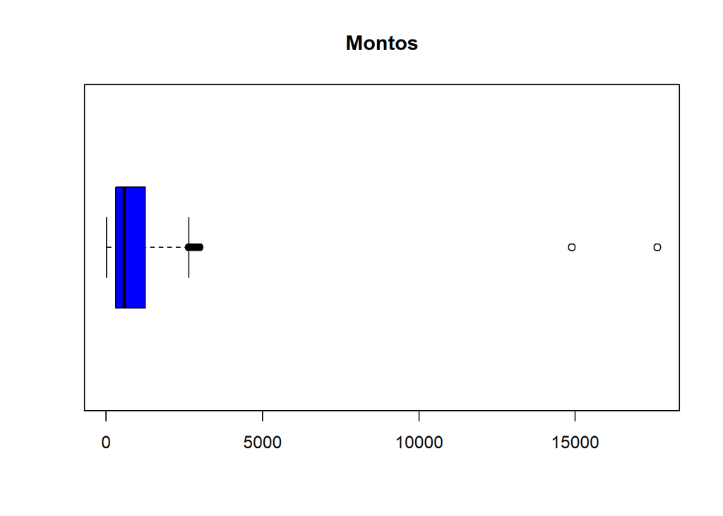

```r
#Elimino datos atípicos(outliers) de la variable "Monto venta"
boxplot(Ventas$`Monto venta`,col = "blue",main = "Montos",horizontal = TRUE)
```

Solo 2 clientes hicieron compras por un monto muy grande. En la parte de la limpieza también hay que tener en cuenta esos datos atípicos (outliers).

```r
Ventas = Ventas[Ventas$`Monto venta`< 6000, ]
```

Del dataset de ventas, tomo únicamente las filas en donde el “monto de venta” es menor que 6000 y dejo coma para tener en cuenta todas las columnas.

Resultado: solamente reduje 2 filas, es decir, había dos datos atípicos (outliers). Después de ejecutar esa línea de código, paso a tener 1497 filas con 13 variables.

Con la función summary puedo verificar que el conjunto de datos esté limpio:

```r
summary(Ventas)
```

```
##       Mes           Producto         Tipo producto         Tienda
##  Min.   : 1.000   Length:1497        Length:1497        Length:1497
##  1st Qu.: 4.000   Class :character   Class :character   Class :character
##  Median : 6.000   Mode  :character   Mode  :character   Mode  :character
##  Mean   : 6.377
##  3rd Qu.: 9.000
##  Max.   :12.000
##      Sector          Compra       Monto venta          Edad
##  Min.   :1.000   Min.   :0.000   Min.   :  20.0   Min.   :15.00
##  1st Qu.:1.000   1st Qu.:0.000   1st Qu.: 321.0   1st Qu.:26.00
##  Median :2.000   Median :0.000   Median : 585.0   Median :38.00
##  Mean   :2.113   Mean   :0.477   Mean   : 874.3   Mean   :37.83
##  3rd Qu.:3.000   3rd Qu.:1.000   3rd Qu.:1250.0   3rd Qu.:49.00
##  Max.   :3.000   Max.   :1.000   Max.   :3000.0   Max.   :60.00
##      Género        Frecuencia    Tipo de compra      Utilidad
##  Min.   :0.000   Min.   :0.000   Min.   :0.0000   Min.   :  17.0
##  1st Qu.:0.000   1st Qu.:1.000   1st Qu.:0.0000   1st Qu.: 272.9
##  Median :1.000   Median :2.000   Median :0.0000   Median : 497.2
##  Mean   :0.507   Mean   :2.299   Mean   :0.3554   Mean   : 743.2
##  3rd Qu.:1.000   3rd Qu.:3.000   3rd Qu.:1.0000   3rd Qu.:1062.5
##  Max.   :1.000   Max.   :4.000   Max.   :1.0000   Max.   :2550.0
##     Nombre
##  Length:1497
##  Class :character
##  Mode  :character
##
##
##
```

### Análisis exploratorio de los datos EDA

El diagrama de caja pertenece a las herramientas de la estadística descriptiva. Permite ver como es la dispersión de los puntos con la mediana, los percentiles 25 y 75 y los valores máximo y mínimo.

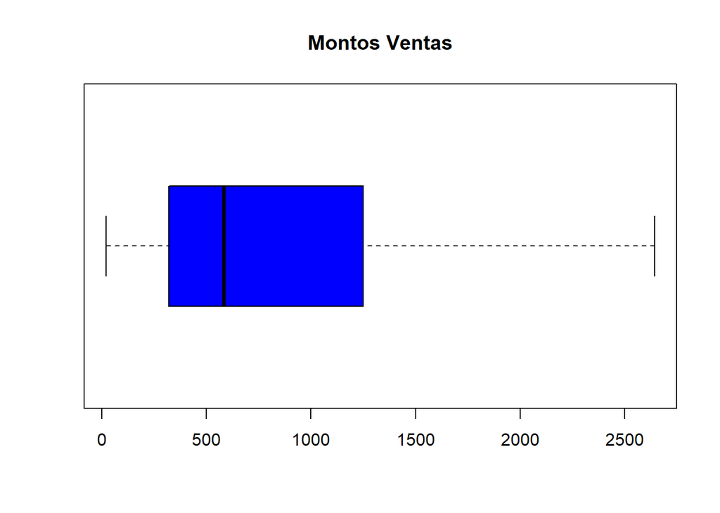

```r
#Gráfico de caja de la variable Monto venta
boxplot(Ventas$`Monto venta`,outline = FALSE,col = "blue",main = "Montos Ventas",horizontal = TRUE)
```

Un boxplot interpreta los cuartiles de mi dataset. Los cuartiles sólo tienen sentido en las variables numéricas (Monto venta), no en las categóricas. Ete gráfico es más apropiado para variables numéricas que tienen infinitas posibilidades.

Los cuartiles lo que me indica es donde se concentra el 25% de mis datos (primer cuartil Q1), el 50% de los datos (el segundo cuartil Q2 o mediana), el 75% de los datos (tercer cuartil Q3). También el mínimo y el máximo de los datos.

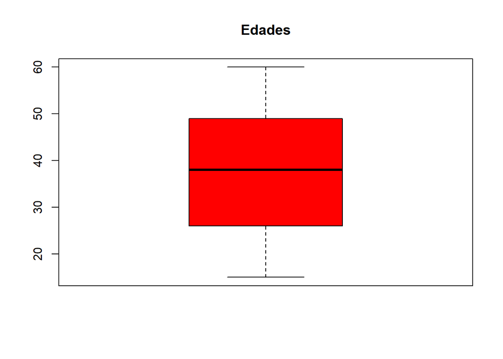

```r
#Gráfico de caja para la variable "Edad"
boxplot(Ventas$Edad,col = "red",main = "Edades")
```

La edad mínima es 15 años y la máxima es 60 años. La mediana de la edad es 38 años, quiere decir el 50% de los clientes están por debajo de 38 años, y el otro 50% con una edad superior a 38 años. El 75% de los clientes tienen menos de 49 años.

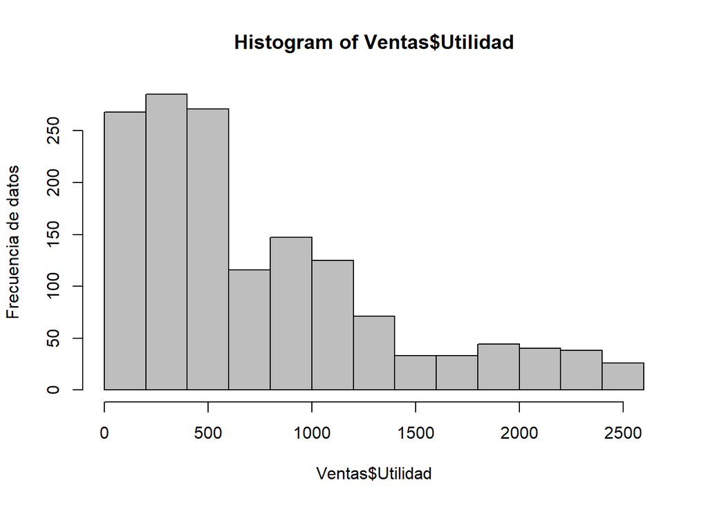

```r
#Histograma
hist(Ventas$Utilidad,col = "grey",ylab = "Frecuencia de datos")
```

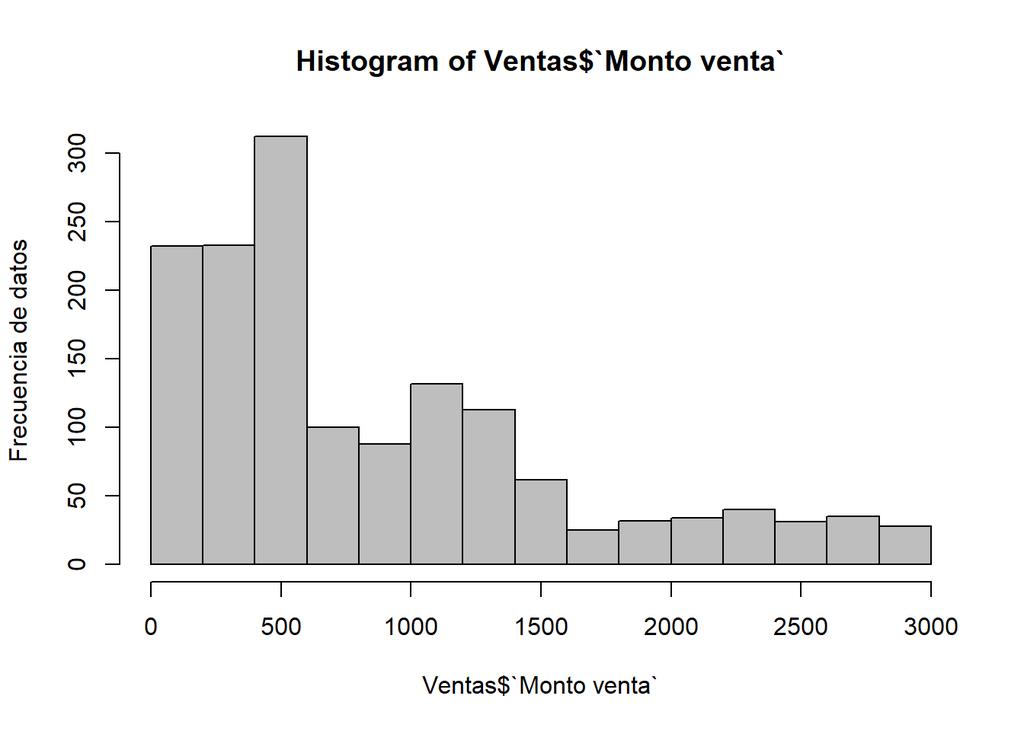

```r
hist(Ventas$`Monto venta`,col = "grey",ylab = "Frecuencia de datos")
```

Un histograma muestra que tanto se frecuentan o repiten los datos. Se observa en la gráfica que la gran mayoría de los montos vendidos se encuentran en montos bajos y entre más alto es el monto de venta menos se frecuentan. Es más escaso un monto alto que un monto bajo.

```r
#Correlación
cor(Ventas$Edad, Ventas$`Monto venta`)
```

```
## [1] -0.7863544
```

Esta función brinda el coeficiente de correlación de dos variables de un dataset. La correlación entre la edad y los montos de venta es de -0.78, esto significa que hay una correlación negativa de 78%. Se puede afirmar con cierto grado de seguridad, que entre más edad tengo, menos monto compra el cliente y menos utilidad genera. Puede ser que los productos estén orientados a jóvenes y la gente mayor no compra tanto y si compra no son montos altos.

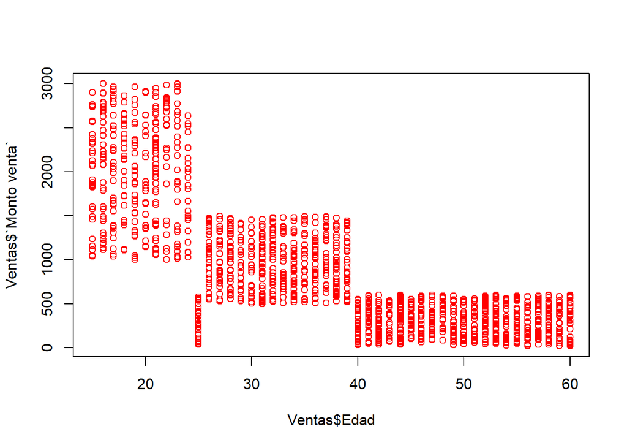

```r
#Crear un gráfico
plot(Ventas$Edad,Ventas$`Monto venta`,col = "red")
```

En el gráfico se observa que cuando la edad aumenta, los montos de venta disminuyen.

##### Media, mediana y desviación estándar de la variable “Monto venta”

```r
mean(Ventas$`Monto venta`)
```

```
## [1] 874.3273
```

```r
median(Ventas$`Monto venta`)
```

```
## [1] 585
```

```r
sd(Ventas$`Monto venta`)
```

```
## [1] 733.6265
```

##### Media, mediana y desviación estándar de la variable “Edad”

```r
mean(Ventas$Edad)
```

```
## [1] 37.83367
```

```r
median(Ventas$Edad)
```

```
## [1] 38
```

```r
sd(Ventas$Edad)
```

```
## [1] 13.34912
```

#### Gráficos en R con ggplot2

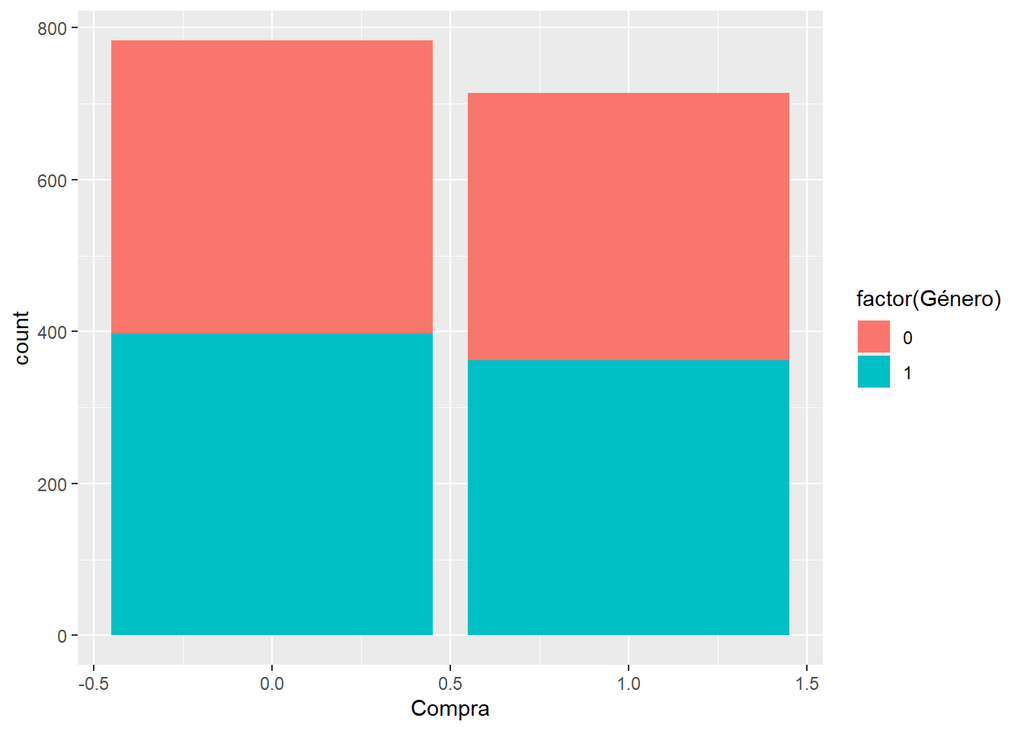

```r
ggplot(data = Ventas,aes(Compra)) + geom_bar(aes(fill = factor(Género)))
```

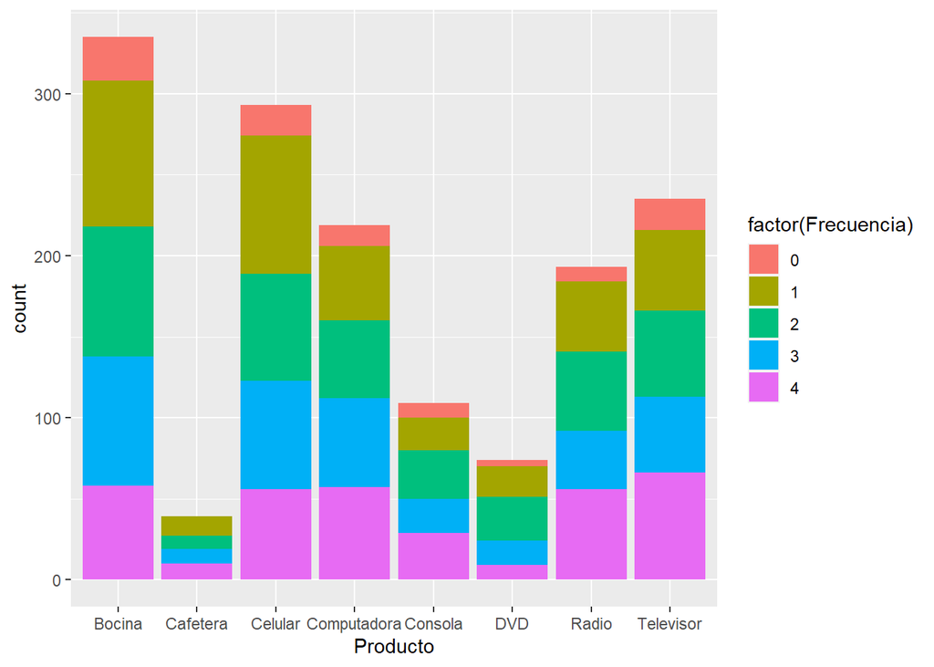

```r
ggplot(data = Ventas,aes(Producto)) + geom_bar(aes(fill = factor(Frecuencia)))
```

### Conclusiones

- Se deben borrar los datos faltantes porque distorsionan el análisis de los datos. No se puede eliminar solamente una celda, hay que borrar toda la fila. Por ello, en la parte de limpieza de datos el número de filas (observaciones) disminuye.
- Para realizar el análisis exploratorio de los datos EDA, primero hay que hacer limpmieza de datos.
- La correlación entre la edad y los montos de venta es de -0.78, esto significa que hay una correlación negativa de 78%. Se puede afirmar con cierto grado de seguridad, que entre más edad tengo, menos monto compra el cliente y menos utilidad genera. Puede ser que los productos estén orientados a jóvenes y la gente mayor no compra tanto y si compra no son montos altos.